# BCB420 Assignment 2: Differential Gene Expression Analysis and Preliminary ORA

Veronica Chang

March 20th, 2023

# Introduction

## Background

Multiple sclerosis (MS) is a chronic neuroinflammatory autoimmune disease. MS is characterized by demyelination and subsequent formation of lesions through out the central nervous system (CNS). Grey matter (GM) and white matter (WM) lesions in the brain show pathological differences. Microglia are CNS-resident and can function as antigen-presenting cells and phagocytes. Their role in MS is complex and controversial (Luo 2017). In this paper by van der Poel et. al, titled “Transcriptional profiling of human microglia reveals grey-white matter heterogeneity and multiple sclerosis-associated changes”, a total of 31 human microglia samples were analyzed from 10 MS donors (MS), including 5 grey matter (GM) and 10 white matter (WM) samples, and from 11 non-neurological control donors (CON), including 5 grey matter and 11 white matter samples. From each sample, the total RNA was extracted (Poel 2019).

## Objectives

The authors isolated human microglia according to the previously described general experimental design. They suggest that pathological changes in MS tissue may be associated with changes in microglia, leading to lesion initiation. The authors wanted to analyze the transcriptional profile of microglia in the collected samples by RNA-sequencing (Poel 2019). Ultimately, they wanted to discover MS-related changes in microglia between the GM and WM brain regions.

## Dataset

After our previous analysis in A1, the final dataset was made up of:

```
- 15076 with unique identifiers

- 31 samples in total

- 2 patient groups *MS* and *CON*, and 2 tissues *GM*, *WM*

- 10 MS patients and 11 CON

- 10 replicates for WM in the MS group and 11 replicates in the CON group

- 5 replicates for GM in both patient groups.
```

## Previous Analysis

In the previous assignment, A1, we used the dataset ID GSE111972, from the publication “Transcriptional profiling of human microglia reveals grey-white matter heterogeneity and multiple sclerosis-associated changes” by van der Poel et. al (Poel (2019)). In A1, we conducted data cleaning, normalization, gene mapping, and preliminary analysis. We filtered out the lowly expressed genes and were left with 15076 genes compared to the original 21283. A total of 6207 genes were removed. The number of genes did not change after normalization. Genes were already mapped to HUGO gene symbols. When we generated a MDS plot post-normalization, we saw that the tissues GM and WM clustered relatively well with each other regardless of which patient group they were obtained from.

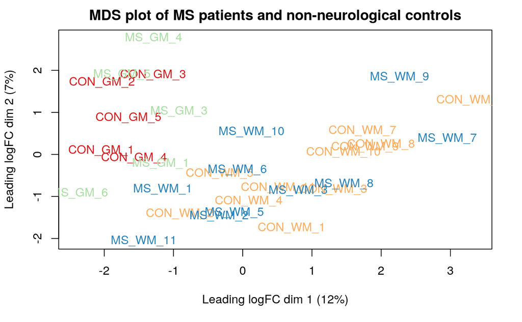

```r
knitr::include_graphics("~/projects/A2/figures/a1_mdsplot.png")
```

## Packages

- BiocManager (Morgan 2022)
- [GEOmetadb](https://bioconductor.org/packages/release/bioc/html/GEOmetadb.html) (Zhu 2008)
- [limma](https://bioconductor.org/packages/release/bioc/html/limma.html) (Smyth 2015)
- [edgeR](https://bioconductor.org/packages/release/bioc/html/edgeR.html) (Robinson 2010)
- [biomaRt](https://bioconductor.org/packages/release/bioc/html/biomaRt.html) (Durinck 2009)
- [GEOquery](https://bioconductor.org/packages/release/bioc/html/GEOquery.html) (Davis 2007)
- [Biobase](https://bioconductor.org/packages/release/bioc/html/Biobase.html) (Huber 2015)
- RColorBrewer (Neuwirth 2022)

```r
if (!requireNamespace("BiocManager", quietly = TRUE))
    install.packages("BiocManager")
if (!requireNamespace("GEOmetadb", quietly = TRUE))
    BiocManager::install("GEOmetadb")

library("BiocManager")
library("GEOmetadb")
library("limma")
library("edgeR")
library("biomaRt")
library("dplyr")
library("Biobase")
library("GEOquery")
library("ComplexHeatmap")
library("circlize")
library("RColorBrewer")
library("ggplot2")
library("knitr")
library("ggrepel")
library("RSQLite")
library("kableExtra")
```

# Task 1: Differential Gene Expression

## Import data

For our analysis in A1, we saved our data output to a .csv file. We will need to load the data file to use in our analysis for this assignment.

```r
# Load the data file
counts <- read.csv(file = "~/projects/expDataNorm.csv", header = TRUE, row.names = 1)

# View some of the data
head(counts)
```

|  | CON_GM_1 | CON_WM_2 | CON_GM_2 | CON_WM_5 | CON_GM_3 | CON_WM_7 | CON_GM_4 | CON_WM_9 | CON_GM_5 | CON_WM_11 | CON_WM_1 | CON_WM_10 | CON_WM_3 | CON_WM_4 | CON_WM_6 | CON_WM_8 | MS_GM_1 | MS_WM_2 | MS_GM_3 | MS_WM_5 | MS_GM_4 | MS_WM_6 | MS_GM_5 | MS_WM_10 | MS_GM_6 | MS_WM_11 | MS_WM_1 | MS_WM_3 | MS_WM_7 | … |
| --- | --- | --- | --- | --- | --- | --- | --- | --- | --- | --- | --- | --- | --- | --- | --- | --- | --- | --- | --- | --- | --- | --- | --- | --- | --- | --- | --- | --- | --- | --- |
| A1BG | 2.322384 | 0.000000 | 0.000000 | 9.7103050 | 3.869484 | 3.581415 | 4.6494765 | 4.3024563 | 1.6266258 | 6.6811974 | 2.721205 | 5.967154 | 5.044565 | 5.765032 | 4.927762 | 4.138293 | 0.8554522 | 1.7738489 | 3.213864 | 8.109043 | 0.000000 | 0.5555056 | 0.000000 | 12.962222 | 6.125865 | 6.952920 | 3.7862735 | 4.585508 | 12.605553 | … |
| A1BG-AS1 | 0.000000 | 0.000000 | 2.147662 | 2.7131785 | 1.893581 | 3.038778 | 0.8796305 | 2.8840632 | 0.0000000 | 0.7107671 | 0.000000 | 2.893158 | 3.189096 | 6.830349 | 0.000000 | 3.092826 | 2.1101195 | 0.7712382 | 7.026943 | 2.818393 | 0.424570 | 0.0000000 | 1.288421 | 0.000000 | 1.842358 | 4.924984 | 4.1825111 | 6.659921 | 0.000000 | … |
| A2M | 2375.117180 | 2701.025776 | 1721.380356 | 2100.3562559 | 1577.677495 | 1649.732735 | 2074.3340980 | 1617.0633547 | 2213.6882390 | 3197.1069714 | 1326.416102 | 3195.496481 | 3035.030794 | 2534.298386 | 1447.317083 | 2292.614345 | 2769.1598155 | 2908.2613390 | 2767.027859 | 4925.558242 | 1758.502806 | 2804.6216787 | 882.469511 | 482.940011 | 2940.128917 | 4643.169744 | 4741.5600681 | 3959.859310 | 1080.547077 | … |
| A2M-AS1 | 45.339311 | 30.898561 | 5.238205 | 2.2847837 | 7.203817 | 7.759746 | 22.4096463 | 16.6424430 | 13.1116144 | 5.4018379 | 18.198070 | 5.741091 | 11.016874 | 12.908673 | 22.694817 | 6.098517 | 14.7708421 | 2.4679610 | 0.000000 | 5.340111 | 35.631234 | 12.6531833 | 11.149776 | 16.235510 | 36.801178 | 7.387445 | 10.3021788 | 7.205801 | 8.382692 | … |
| A4GALT | 0.000000 | 0.000000 | 0.000000 | 0.8567953 | 1.029117 | 1.899236 | 1.0890661 | 0.9928763 | 0.6407906 | 1.1372296 | 0.000000 | 7.549315 | 1.507570 | 1.691917 | 19.213744 | 6.839044 | 0.0000000 | 4.3189303 | 0.000000 | 0.000000 | 2.090191 | 4.4440436 | 6.541223 | 1.833040 | 0.000000 | 0.000000 | 0.5283173 | 3.220773 | 4.853136 | … |
| AAAS | 39.955610 | 3.212694 | 35.095946 | 28.2741941 | 18.935813 | 30.984699 | 33.4678486 | 41.3224504 | 35.3421322 | 22.8156716 | 16.157172 | 25.360363 | 26.382521 | 13.848604 | 42.496296 | 23.697189 | 22.3558340 | 27.3789378 | 29.578444 | 25.118292 | 41.673185 | 28.3924863 | 24.133136 | 4.582599 | 55.178716 | 24.552482 | 11.2707926 | 26.639626 | 21.051274 | … |

```r
# Also loaded in the samples categories into a table
expSamples <- read.csv("~/projects/expSamples.csv", header = TRUE)
```

**Table 1.** First few rows of a table of the normalized data counts of the chosen gene set. There are 15076 genes from 31 samples. Each gene has a unique HGNC symbol identifier. The samples can be divided into (1) `patient_group`, MS and CON, where MS includes the multiple sclerosis donor samples and CON is the non-neurological control donors, (2) `tissue`, GM and WM, where GM includes grey matter samples and WM includes white matter samples.

## Design model

We will be using the package `edgeR` for this assignment. edgeR uses a generalized linear model to test for differential expression of RNA-seq expression profiles. We need to consider how there are two major factors in our data set - `patient_group` and `tissue`. Ideally, we would account for both in our design model. We already defined a group that has both of these factors in A1.

```r
# Define the groups
groups <- paste(expSamples$group)
groups <- factor(groups)

# Create design with groups
modelDesign <- model.matrix(~0 + groups)
colnames(modelDesign) <- c("CON.GM", "CON.WM", "MS.GM", "MS.WM")
DT::datatable(modelDesign[order(gsub("M[0-9]{2}\\.", "", rownames(modelDesign))),
    ], rownames = TRUE, options = list(pageLength = 5, scrollX = TRUE)) %>%
    DT::formatStyle(names(modelDesign), fontSize = "10px")
```

|  | CON.GM | CON.WM | MS.GM | MS.WM |
| --- | --- | --- | --- | --- |
| 1 | 1 | 0 | 0 | 0 |
| 10 | 0 | 1 | 0 | 0 |
| 11 | 0 | 1 | 0 | 0 |
| 12 | 0 | 1 | 0 | 0 |
| 13 | 0 | 1 | 0 | 0 |
| 14 | 0 | 1 | 0 | 0 |
| 15 | 0 | 1 | 0 | 0 |
| 16 | 0 | 1 | 0 | 0 |
| 17 | 0 | 0 | 1 | 0 |
| 18 | 0 | 0 | 0 | 1 |

[output cut: 21 more lines]

**Table 2.** Differential expression analysis model design, includes both `patient_group` and `tissue` as factors.

Since we are using `edgeR` for downstream analysis, we will first need to create a DGEList object, this will hold the dataset that will be analyzed by edgeR. We will also evaluate the dispersion. We will be using a Quasi-likelihood model as our dataset is of RNA-Seq data and Quasi-likelihood models are best suited. However, Quasi-likelihood models require that the data follows a negative binomial distribution so will want to confirm whether our data set follows this.

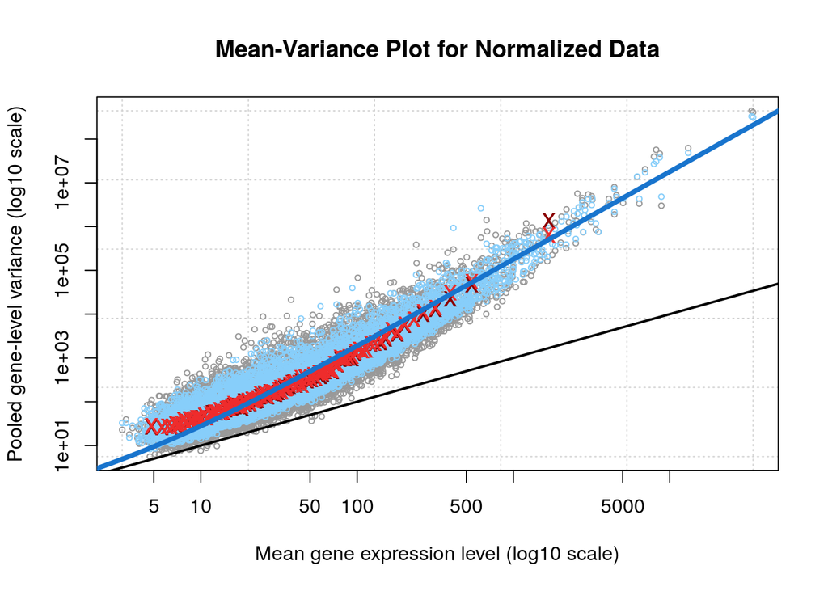

```r
# Create DGEList
dgeCounts <- edgeR::DGEList(counts = counts, group = groups)

# Remove lowly expressed genes
keep.exprs <- filterByExpr(dgeCounts, group = groups)
dgeCounts <- dgeCounts[keep.exprs, , keep.lib.sizes = FALSE]
dgeCounts <- edgeR::calcNormFactors(dgeCounts)

# Check dispersion
dgeCounts <- edgeR::estimateDisp(dgeCounts, modelDesign)

edgeR::plotMeanVar(dgeCounts, show.raw.vars = TRUE, show.tagwise.vars = TRUE, NBline = TRUE,
    show.ave.raw.vars = TRUE, show.binned.common.disp.vars = TRUE, main = "Mean-Variance Plot for Normalized Data")
```

**Figure 1.** Mean-variance relationship of normalized data. Dispersion estimation is done with the negative binomial model, which estimates the common, trended and tagwise dispersions across all tags. The grey and light blue points show the mean and pooled variance for each gene. The red crosses show binned variance, in which genes are grouped by mean level. The blue line indicates the common dispersion and is based on the negative binomial model. The black line displays the theoretical variance under the Poisson distribution model where the variance is equal to the mean.

In order to make accurate inferences about differential expression, we need to appropriately model the mean-variance relationship in DEGs. As we can see in Fig. 1, our normalized data set follows the negative binomial distribution. We can now verify that we can use a Quasi-likelihood model and fit our data to our model.

## Fit the data

```r
fit <- edgeR::glmQLFit(dgeCounts, modelDesign)
```

We have now fit our model and can move to differential expression analysis.

## MS vs CON

We will be testing for differential expression between the MS and CON samples for each tissue. We want to also adjust the p-values using the Benjamini-Hochberg method as we are doing multiple comparisons. This method assumes that the power to detect differential expression is equally likely among all the tests - reducing the false discovery rate.

```r
# Create a contrast for the patient groups GM
contrast_gm <- limma::makeContrasts("MS.GM - CON.GM", levels = modelDesign)

# Create a contrast for the patient groups WM
contrast_wm <- limma::makeContrasts("MS.WM - CON.WM", levels = modelDesign)

# Perform DE analysis
qlf_gm <- edgeR::glmQLFTest(glmfit = fit, contrast = contrast_gm)

qlf_wm <- edgeR::glmQLFTest(glmfit = fit, contrast = contrast_wm)

# Extract the top DE hits ranked by p-value
results_gm <- edgeR::topTags(qlf_gm, sort.by = "PValue", adjust.method = "BH", n = nrow(dgeCounts))$table

results_wm <- edgeR::topTags(qlf_wm, sort.by = "PValue", adjust.method = "BH", n = nrow(dgeCounts))$table
```

We can examine the DE genes pass the threshold and correction. We are using 0.05 as the threshold for the p-value by convention.

```r
# DE genes of unadjusted p-value < 0.05
sum(results_gm$PValue < 0.05)
```

```
## [1] 572
```

```r
sum(results_wm$PValue < 0.05)
```

```
## [1] 729
```

We actually have a lot of DE genes with p-value < 0.05, we might want to consider bringing this p-value threshold down to 0.01.

```r
sum(results_gm$PValue < 0.01)
```

```
## [1] 113
```

```r
sum(results_wm$PValue < 0.01)
```

```
## [1] 176
```

We can see that we have `113` DE genes in the grey matter samples between `CON` and `MS.` We have `176` genes in the white matter samples between `CON` and `MS.`

We should now look at FDR as a “true” indicator of differential expression.

```r
# DE genes of p-value < 0.05
sum(results_gm$FDR < 0.05)
```

```
## [1] 4
```

```r
sum(results_wm$FDR < 0.05)
```

```
## [1] 0
```

Interestingly, there are not many DE genes for the GM comparison - only 4 and all of them are up-regulated. For the WM comparison, there are none. This makes sense as in the MDS we obtained from A1, we saw that the samples cluster together by tissue despite the patient group. From now on, our analysis will be focused on comparing the GM and WM in the two patient groups.

## GM vs WM

We will be testing for differential expression between the different tissues for each patient group. We want to also adjust the p-values using the Benjamini-Hochberg method as we are doing multiple comparisons. This method assumes that the power to detect differential expression is equally likely among all the tests - reducing the false discovery rate.

```r
# Create a contrast for the MS GM and WM
contrast_ms <- limma::makeContrasts("MS.GM - MS.WM", levels = modelDesign)

# Create a contrast for the CON GM and WM
contrast_con <- limma::makeContrasts("CON.GM - CON.WM", levels = modelDesign)

# Perform DE analysis
qlf_ms <- edgeR::glmQLFTest(glmfit = fit, contrast = contrast_ms)

qlf_con <- edgeR::glmQLFTest(glmfit = fit, contrast = contrast_con)

# Extract the top DE hits ranked by p-value
results_ms <- edgeR::topTags(qlf_ms, sort.by = "PValue", adjust.method = "BH", n = nrow(dgeCounts))$table

results_con <- edgeR::topTags(qlf_con, sort.by = "PValue", adjust.method = "BH",
    n = nrow(dgeCounts))$table
```

We can examine the DE genes pass the threshold and correction. We are using 0.05 as the threshold for the p-value by convention.

```r
# DE genes of p-value < 0.05
sum(results_ms$PValue < 0.05)
```

```
## [1] 3042
```

```r
sum(results_con$PValue < 0.05)
```

```
## [1] 2901
```

Interestingly, there are differences between the tissues for each patient group. There are many genes so we will also bring the p-value threshold down to 0.01 for this comparison.

```r
# DE genes of p-value < 0.01
sum(results_ms$PValue < 0.01)
```

```
## [1] 1621
```

```r
sum(results_con$PValue < 0.01)
```

```
## [1] 1498
```

We should now look at FDR as a “true” indicator of differential expression.

```r
# DE genes of p-value < 0.05
sum(results_ms$FDR < 0.05)
```

```
## [1] 1321
```

```r
sum(results_con$FDR < 0.05)
```

```
## [1] 1104
```

```r
# DE genes of p-value < 0.01
sum(results_ms$FDR < 0.01)
```

```
## [1] 444
```

```r
sum(results_con$FDR < 0.01)
```

```
## [1] 365
```

## Volcano plot GM vs WM

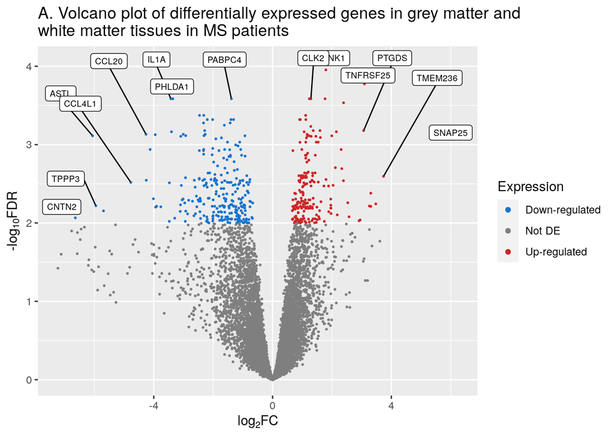

```r
# Label genes
results_ms <- results_ms %>%
    dplyr::mutate(Expression = dplyr::case_when(logFC > 0 & FDR < 0.01 ~ "Up-regulated",
        logFC < 0 & FDR < 0.01 ~ "Down-regulated", TRUE ~ "Not DE"))

# Plot volcano plot
ggplot2::ggplot(results_ms, aes(logFC, -log(FDR, 10))) + labs(title = "A. Volcano plot of differentially expressed genes in grey matter and
white matter tissues in MS patients") +
    ggplot2::geom_point(aes(color = Expression), size = 2/5) + xlab(expression("log"[2] *
    "FC")) + ylab(expression("-log"[10] * "FDR")) + ggplot2::scale_color_manual(values = c(`Up-regulated` = "firebrick3",
    `Down-regulated` = "dodgerblue3", `Not DE` = "gray50")) + ggplot2::guides(color = ggplot2::guide_legend(override.aes = list(size = 1.5))) +
    ggrepel::geom_label_repel(data = results_ms, mapping = aes(logFC, -log(FDR, 10),
        label = rownames(results_ms)), size = 2.5, color = "black", nudge_x = 0.1,
        nudge_y = 0.1)
```

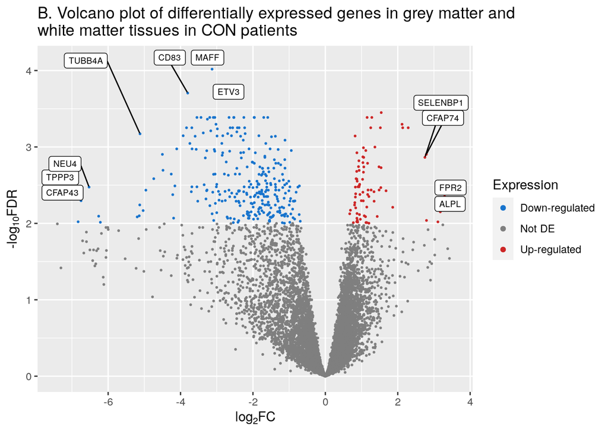

```r
# Label genes
results_con <- results_con %>%
    dplyr::mutate(Expression = dplyr::case_when(logFC > 0 & FDR < 0.01 ~ "Up-regulated",
        logFC < 0 & FDR < 0.01 ~ "Down-regulated", TRUE ~ "Not DE"))

# Plot volcano plot
ggplot2::ggplot(results_con, aes(logFC, -log(FDR, 10))) + labs(title = "B. Volcano plot of differentially expressed genes in grey matter and
white matter tissues in CON patients") +
    ggplot2::geom_point(aes(color = Expression), size = 2/5) + xlab(expression("log"[2] *
    "FC")) + ylab(expression("-log"[10] * "FDR")) + ggplot2::scale_color_manual(values = c(`Up-regulated` = "firebrick3",
    `Down-regulated` = "dodgerblue3", `Not DE` = "gray50")) + ggplot2::guides(color = ggplot2::guide_legend(override.aes = list(size = 1.5))) +
    ggrepel::geom_label_repel(data = results_con, mapping = aes(logFC, -log(FDR,
        10), label = rownames(results_con)), size = 2.5, color = "black", nudge_x = 0.1,
        nudge_y = 0.1)
```

For the MS patients, the most up-regulated gene was `SNAP25` with a logFC of `6.482862` and the most down-regulated gene was `CNTN2` with a logFC of `-6.641904`. For the CON patients, the most up-regulated gene was `FPR2` with a logFC of `3.2941815` and the most down-regulated gene was `CFAP43` with a logFC of `-7.137068`.

## Heat map

We can better visualize global expression change over our samples with a heat map. In this heatmap, all the groups - CON GM, CON WM, MS GM, MS WM will be compared against each other.

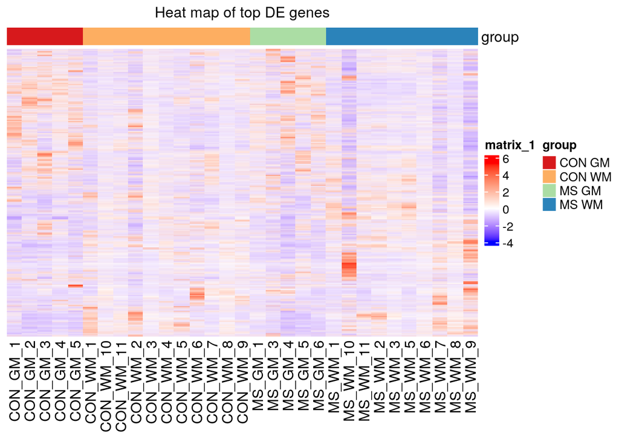

```r
# Create a heat map matrix to scale counts to CPM
dgeCounts <- edgeR::calcNormFactors(dgeCounts)
dgeCountsAll <- edgeR::cpm(dgeCounts)

hmapMatrix <- dgeCountsAll
rownames(hmapMatrix) <- rownames(dgeCountsAll)
colnames(hmapMatrix) <- colnames(dgeCountsAll)
hmapMatrix <- dgeCountsAll %>%
    t() %>%
    scale() %>%
    t()

# In A1, I already defined a colour annotation for the groups, as below:
annoCol <- brewer.pal(4, "Spectral")
names(annoCol) <- c("CON GM", "CON WM", "MS GM", "MS WM")
annoCol <- list(group = annoCol)

# Make annotation dataframe
annoDF <- data.frame(group = expSamples$group)

# Create the heat map annotation
hmapAnno <- ComplexHeatmap::HeatmapAnnotation(df = annoDF, col = annoCol)

# Check range of heat map matrix and set colour
hmapRange <- range(hmapMatrix)
hmapCol <- circlize::colorRamp2(c(hmapRange[1], 0, hmapRange[2]), c("blue", "white",
    "red"))

# Create heat map
hmapDEG <- ComplexHeatmap::Heatmap(hmapMatrix, show_column_dend = FALSE, show_row_dend = FALSE,
    show_column_names = TRUE, show_row_names = FALSE, row_names_gp = gpar(cex = 0.5),
    cluster_rows = TRUE, column_order = sort(colnames(hmapMatrix)), col = hmapCol,
    top_annotation = hmapAnno)

draw(hmapDEG, column_title = "Heat map of top DE genes", column_title_gp = grid::gpar(fontsize = 12))
```

## Differential expression analysis discussion

### 1. Calculate p-values for each of the genes in your expression set. How many genes were significantly differentially expressed? What thresholds did you use and why?

I first used the conventionally used p-value of 0.05 for both sets of analysis. This resulted to `572` genes that were differentially expressed in `GM` between MS and CON, and `729` genes that were differentially expressed in `WM` between MS and CON. The comparison of the two tissues, GM and WM, resulted to `3042` genes that were differentially expressed in `MS` patients, and `2901` genes that were differentially expressed in `CON` patients. Since there were still many genes, I reduced the p-value to 0.01. This decreased the number of DE genes to `113`, `176`, `1621`, and `1498` respectively.

### 3. Show the amount of differentially expressed genes using an MA Plot or a Volcano plot. Highlight genes of interest.

Volcano plot for MS and CON patients with the comparison of GM vs WM tissue samples. The top DE genes are labelled for each plot.

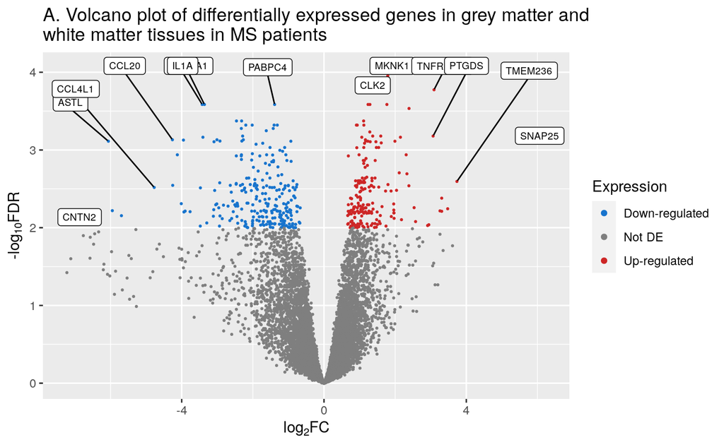

```r
knitr::include_graphics("~/projects/A2/figures/a2_volcanoms.png")
```

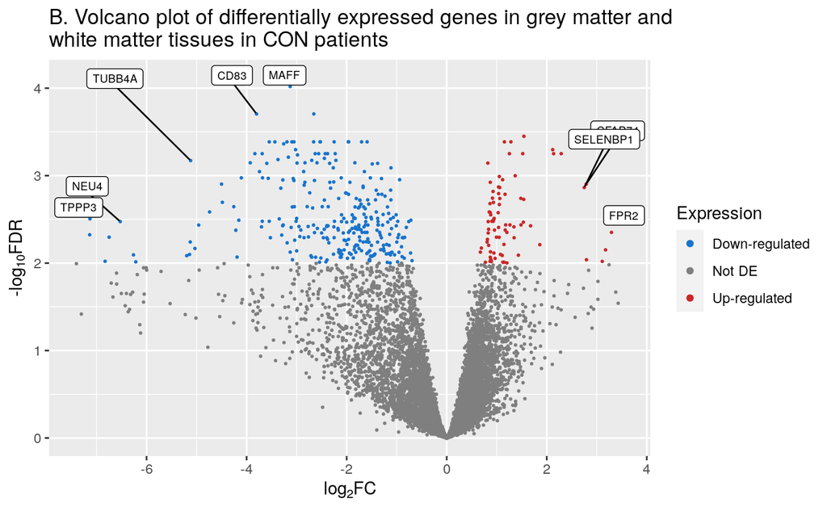

```r
knitr::include_graphics("~/projects/A2/figures/a2_volcanocon.png")
```

For the MS patients, the most up-regulated gene was `SNAP25` with a logFC of `6.482862` and the most down-regulated gene was `CNTN2` with a logFC of `-6.641904`. For the CON patients, the most up-regulated gene was `FPR2` with a logFC of `3.2941815` and the most down-regulated gene was `CFAP43` with a logFC of `-7.137068`.

### 4. Visualize your top hits using a heatmap. Do your conditions cluster together? Explain why or why not.

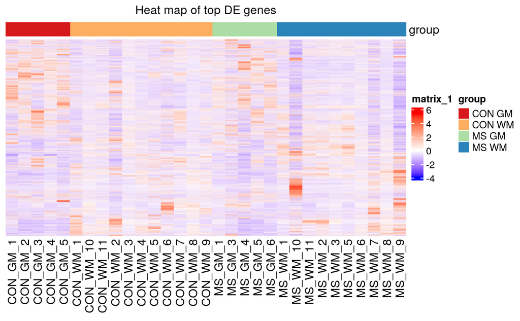

```r
knitr::include_graphics("~/projects/A2/figures/a2_heatmap.png")
```

For both patient groups, we can see similarities in the genes that down- and up-regulated, i.e. genes that are up-regulated in GM in CON patients will be up-regulated in MS patients. This relates to what we saw in our MDS plot from A1 that was shown in the introduction section of this assignment. Samples of the same tissue cluster regardless of patient group.

# Task 2: Thresholded Overrepresentation Analysis using g:Profiler

For this part of the assignment, we will be doing a thresholded over-representation analysis with g:Profiler.

## MS GM vs WM

```r
# Define the groups
msUpregulated <- results_ms[results_ms$logFC > 0 & results_ms$PValue < 0.01, ]
msDownregulated <- results_ms[results_ms$logFC < 0 & results_ms$PValue < 0.01, ]
```

To perform the gene enrichment analysis, we will use the R package for g:Profiler. We used FDR for correction. In our previous course journal entry assignment, we used GO Biological Process (GO:BP), Reactome (REAC), and WikiPathways (WP) - we will be using these sources in this section.

We will be performing the analysis for up-regulated genes and down-regulated genes separately.

### Up-regulated

```r
# Up-regulated
msUpTopTerms <- gprofiler2::gost(query = rownames(msUpregulated), organism = "hsapiens",
    exclude_iea = TRUE, correction_method = "fdr", sources = c("GO:BP", "REAC", "WP"))

# Limit term size
msUpTopTerms <- data.frame(term_name = msUpTopTerms$result$term_name[msUpTopTerms$result$term_size <
    500 & msUpTopTerms$result$term_size > 1], term_id = msUpTopTerms$result$term_id[msUpTopTerms$result$term_size <
    500 & msUpTopTerms$result$term_size > 1], source = msUpTopTerms$result$source[msUpTopTerms$result$term_size <
    500 & msUpTopTerms$result$term_size > 1])

# Visualize our results
knitr::kable(head(msUpTopTerms, 10), format = "html")
```

| term_name | term_id | source |
| --- | --- | --- |
| regulation of DNA-binding transcription factor activity | GO:0051090 | GO:BP |
| Diseases of Immune System | REAC:R-HSA-5260271 | REAC |
| Diseases associated with the TLR signaling cascade | REAC:R-HSA-5602358 | REAC |
| Toll-like Receptor Cascades | REAC:R-HSA-168898 | REAC |
| Toll Like Receptor 4 (TLR4) Cascade | REAC:R-HSA-166016 | REAC |
| Toll Like Receptor 2 (TLR2) Cascade | REAC:R-HSA-181438 | REAC |
| Toll Like Receptor TLR6:TLR2 Cascade | REAC:R-HSA-168188 | REAC |
| Toll Like Receptor TLR1:TLR2 Cascade | REAC:R-HSA-168179 | REAC |
| MyD88:MAL(TIRAP) cascade initiated on plasma membrane | REAC:R-HSA-166058 | REAC |
| IRAK4 deficiency (TLR2/4) | REAC:R-HSA-5603041 | REAC |

**Table 2.** The first top 10 terms across all the three sources, GO Biological Process (GO:BP), Reactome (REAC), and WikiPathways (WP). The ID of each term is also included.

Number of terms:

```r
length(msUpTopTerms$term_name)
```

```
## [1] 15
```

We are going to want to look at the top terms for each source eventually, so we can look at it now.

```r
knitr::kable(rbind(msUpTopTerms[msUpTopTerms$source == "GO:BP", ][1, ], msUpTopTerms[msUpTopTerms$source ==
    "REAC", ][1, ], msUpTopTerms[msUpTopTerms$source == "WP", ][1, ]), format = "html")
```

|  | term_name | term_id | source |
| --- | --- | --- | --- |
| 1 | regulation of DNA-binding transcription factor activity | GO:0051090 | GO:BP |
| 2 | Diseases of Immune System | REAC:R-HSA-5260271 | REAC |
| 11 | Host-pathogen interaction of human coronaviruses - interferon induction | WP:WP4880 | WP |

**Table 3.** The top term from each of the three sources, GO Biological Process (GO:BP), Reactome (REAC), and WikiPathways (WP). The ID of each term is also included.

### Down-regulated

Now, do the same for the down-regulated genes.

```r
# Down-regulated
msDownTopTerms <- gprofiler2::gost(query = rownames(msDownregulated), organism = "hsapiens",
    exclude_iea = TRUE, correction_method = "fdr", sources = c("GO:BP", "REAC", "WP"))

# Limit term size
msDownTopTerms <- data.frame(term_name = msDownTopTerms$result$term_name[msDownTopTerms$result$term_size <
    500 & msDownTopTerms$result$term_size > 1], term_id = msDownTopTerms$result$term_id[msDownTopTerms$result$term_size <
    500 & msDownTopTerms$result$term_size > 1], source = msDownTopTerms$result$source[msDownTopTerms$result$term_size <
    500 & msDownTopTerms$result$term_size > 1])

# Visualize our results
knitr::kable(head(msDownTopTerms, 10), format = "html")
```

| term_name | term_id | source |
| --- | --- | --- |
| cytoplasmic translation | GO:0002181 | GO:BP |
| translational initiation | GO:0006413 | GO:BP |
| response to topologically incorrect protein | GO:0035966 | GO:BP |
| response to unfolded protein | GO:0006986 | GO:BP |
| regulation of translation | GO:0006417 | GO:BP |
| regulation of amide metabolic process | GO:0034248 | GO:BP |
| post-transcriptional regulation of gene expression | GO:0010608 | GO:BP |
| regulation of cellular macromolecule biosynthetic process | GO:2000112 | GO:BP |
| negative regulation of phosphate metabolic process | GO:0045936 | GO:BP |
| regulation of translational initiation | GO:0006446 | GO:BP |

**Table 4.** The first top 10 terms across all the three sources, GO Biological Process (GO:BP), Reactome (REAC), and WikiPathways (WP). The ID of each term is also included.

Number of terms:

```r
length(msDownTopTerms$term_name)
```

```
## [1] 1028
```

We are going to want to look at the top terms for each source eventually, so we can look at it now.

```r
knitr::kable(rbind(msDownTopTerms[msDownTopTerms$source == "GO:BP", ][1, ], msDownTopTerms[msDownTopTerms$source ==
    "REAC", ][1, ], msDownTopTerms[msDownTopTerms$source == "WP", ][1, ]), format = "html")
```

|  | term_name | term_id | source |
| --- | --- | --- | --- |
| 1 | cytoplasmic translation | GO:0002181 | GO:BP |
| 739 | Cap-dependent Translation Initiation | REAC:R-HSA-72737 | REAC |
| 963 | Glucocorticoid receptor pathway | WP:WP2880 | WP |

**Table 5.** The top term from each of the three sources, GO Biological Process (GO:BP), Reactome (REAC), and WikiPathways (WP). The ID of each term is also included.

### All DE genes

```r
# Up-regulated
msAllTopTerms <- gprofiler2::gost(query = rownames(results_ms), organism = "hsapiens",
    exclude_iea = TRUE, correction_method = "fdr", sources = c("GO:BP", "REAC", "WP"))

# Limit term size
msAllTopTerms <- data.frame(term_name = msAllTopTerms$result$term_name[msAllTopTerms$result$term_size <
    500 & msAllTopTerms$result$term_size > 1], term_id = msAllTopTerms$result$term_id[msAllTopTerms$result$term_size <
    500 & msAllTopTerms$result$term_size > 1], source = msAllTopTerms$result$source[msAllTopTerms$result$term_size <
    500 & msAllTopTerms$result$term_size > 1])

# Visualize our results
knitr::kable(head(msAllTopTerms, 10), format = "html")
```

| term_name | term_id | source |
| --- | --- | --- |
| ribonucleoprotein complex biogenesis | GO:0022613 | GO:BP |
| process utilizing autophagic mechanism | GO:0061919 | GO:BP |
| autophagy | GO:0006914 | GO:BP |
| RNA splicing | GO:0008380 | GO:BP |
| ribosome biogenesis | GO:0042254 | GO:BP |
| regulation of amide metabolic process | GO:0034248 | GO:BP |
| macroautophagy | GO:0016236 | GO:BP |
| mRNA processing | GO:0006397 | GO:BP |
| histone modification | GO:0016570 | GO:BP |
| proteasomal protein catabolic process | GO:0010498 | GO:BP |

**Table 6.** The first top 10 terms across all the three sources, GO Biological Process (GO:BP), Reactome (REAC), and WikiPathways (WP). The ID of each term is also included.

Number of terms:

```r
length(msAllTopTerms$term_name)
```

```
## [1] 2276
```

Look for the top terms from each source:

```r
knitr::kable(rbind(msAllTopTerms[msAllTopTerms$source == "GO:BP", ][1, ], msAllTopTerms[msAllTopTerms$source ==
    "REAC", ][1, ], msAllTopTerms[msAllTopTerms$source == "WP", ][1, ]), format = "html")
```

|  | term_name | term_id | source |
| --- | --- | --- | --- |
| 1 | ribonucleoprotein complex biogenesis | GO:0022613 | GO:BP |
| 1407 | Processing of Capped Intron-Containing Pre-mRNA | REAC:R-HSA-72203 | REAC |
| 2058 | VEGFA-VEGFR2 signaling pathway | WP:WP3888 | WP |

**Table 7.** The top term from each of the three sources, GO Biological Process (GO:BP), Reactome (REAC), and WikiPathways (WP). The ID of each term is also included.

## CON GM vs WM

We will be doing the same analysis for the CON patient group.

```r
# Define the groups
conUpregulated <- results_con[results_con$logFC > 0 & results_con$PValue < 0.01,
    ]
conDownregulated <- results_con[results_con$logFC < 0 & results_con$PValue < 0.01,
    ]
```

To perform the gene enrichment analysis, we will use the R package for g:Profiler. We used FDR for correction. In our previous course journal entry assignment, we used GO Biological Process (GO:BP), Reactome (REAC), and WikiPathways (WP) - we will be using these sources in this section.

We will be performing the analysis for up-regulated genes and down-regulated genes separately.

### Up-regulated

```r
# Up-regulated
conUpTopTerms <- gprofiler2::gost(query = rownames(conUpregulated), organism = "hsapiens",
    exclude_iea = TRUE, correction_method = "fdr", sources = c("GO:BP", "REAC", "WP"))

# Limit term size
conUpTopTerms <- data.frame(term_name = conUpTopTerms$result$term_name[conUpTopTerms$result$term_size <
    500 & conUpTopTerms$result$term_size > 1], term_id = conUpTopTerms$result$term_id[conUpTopTerms$result$term_size <
    500 & conUpTopTerms$result$term_size > 1], source = conUpTopTerms$result$source[conUpTopTerms$result$term_size <
    500 & conUpTopTerms$result$term_size > 1])

# Visualize our results
knitr::kable(head(conUpTopTerms, 10), format = "html")
```

| term_name | term_id | source |
| --- | --- | --- |
| myeloid leukocyte mediated immunity | GO:0002444 | GO:BP |
| regulation of innate immune response | GO:0045088 | GO:BP |
| positive regulation of I-kappaB kinase/NF-kappaB signaling | GO:0043123 | GO:BP |
| regulation of response to biotic stimulus | GO:0002831 | GO:BP |
| positive regulation of defense response | GO:0031349 | GO:BP |
| myeloid leukocyte activation | GO:0002274 | GO:BP |
| lysosome localization | GO:0032418 | GO:BP |
| myeloid cell activation involved in immune response | GO:0002275 | GO:BP |
| vacuolar localization | GO:1990849 | GO:BP |
| regulation of I-kappaB kinase/NF-kappaB signaling | GO:0043122 | GO:BP |

**Table 8.** The first top 10 terms across all the three sources, GO Biological Process (GO:BP), Reactome (REAC), and WikiPathways (WP). The ID of each term is also included.

Number of terms:

```r
length(conUpTopTerms$term_name)
```

```
## [1] 41
```

We are going to want to look at the top terms for each source eventually, so we can look at it now.

```r
knitr::kable(rbind(conUpTopTerms[conUpTopTerms$source == "GO:BP", ][1, ], conUpTopTerms[conUpTopTerms$source ==
    "REAC", ][1, ], conUpTopTerms[conUpTopTerms$source == "WP", ][1, ]), format = "html")
```

|  | term_name | term_id | source |
| --- | --- | --- | --- |
| 1 | myeloid leukocyte mediated immunity | GO:0002444 | GO:BP |
| 35 | Neutrophil degranulation | REAC:R-HSA-6798695 | REAC |
| NA | NA | NA | NA |

**Table 9.** The top term from each of the three sources, GO Biological Process (GO:BP), Reactome (REAC), and WikiPathways (WP). The ID of each term is also included.

Interestingly, there are 0 terms for the WP source.

### Down-regulated

Now, do the same for the down-regulated genes.

```r
# Down-regulated
conDownTopTerms <- gprofiler2::gost(query = rownames(conDownregulated), organism = "hsapiens",
    exclude_iea = TRUE, correction_method = "fdr", sources = c("GO:BP", "REAC", "WP"))

# Limit term size
conDownTopTerms <- data.frame(term_name = conDownTopTerms$result$term_name[conDownTopTerms$result$term_size <
    500 & conDownTopTerms$result$term_size > 1], term_id = conDownTopTerms$result$term_id[conDownTopTerms$result$term_size <
    500 & conDownTopTerms$result$term_size > 1], source = conDownTopTerms$result$source[conDownTopTerms$result$term_size <
    500 & conDownTopTerms$result$term_size > 1])

# Visualize our results
knitr::kable(head(conDownTopTerms, 10), format = "html")
```

| term_name | term_id | source |
| --- | --- | --- |
| cytoplasmic translation | GO:0002181 | GO:BP |
| positive regulation of cell death | GO:0010942 | GO:BP |
| positive regulation of apoptotic process | GO:0043065 | GO:BP |
| positive regulation of programmed cell death | GO:0043068 | GO:BP |
| response to temperature stimulus | GO:0009266 | GO:BP |
| translational initiation | GO:0006413 | GO:BP |
| intrinsic apoptotic signaling pathway | GO:0097193 | GO:BP |
| apoptotic signaling pathway | GO:0097190 | GO:BP |
| response to unfolded protein | GO:0006986 | GO:BP |
| regulation of apoptotic signaling pathway | GO:2001233 | GO:BP |

**Table 10.** The first top 10 terms across all the three sources, GO Biological Process (GO:BP), Reactome (REAC), and WikiPathways (WP). The ID of each term is also included.

Number of terms:

```r
length(conDownTopTerms$term_name)
```

```
## [1] 894
```

We are going to want to look at the top terms for each source eventually, so we can look at it now.

```r
knitr::kable(rbind(conDownTopTerms[conDownTopTerms$source == "GO:BP", ][1, ], conDownTopTerms[conDownTopTerms$source ==
    "REAC", ][1, ], conDownTopTerms[conDownTopTerms$source == "WP", ][1, ]), format = "html")
```

|  | term_name | term_id | source |
| --- | --- | --- | --- |
| 1 | cytoplasmic translation | GO:0002181 | GO:BP |
| 691 | Cap-dependent Translation Initiation | REAC:R-HSA-72737 | REAC |
| 829 | Cytoplasmic ribosomal proteins | WP:WP477 | WP |

**Table 11.** The top term from each of the three sources, GO Biological Process (GO:BP), Reactome (REAC), and WikiPathways (WP). The ID of each term is also included.

```r
knitr::kable(head(conDownTopTerms[conDownTopTerms$source == "WP", ], 10), format = "html")
```

|  | term_name | term_id | source |
| --- | --- | --- | --- |
| 829 | Cytoplasmic ribosomal proteins | WP:WP477 | WP |
| 830 | VEGFA-VEGFR2 signaling pathway | WP:WP3888 | WP |
| 831 | Glucocorticoid receptor pathway | WP:WP2880 | WP |
| 832 | Spinal cord injury | WP:WP2431 | WP |
| 833 | Prostaglandin signaling | WP:WP5088 | WP |
| 834 | IL-18 signaling pathway | WP:WP4754 | WP |
| 835 | Photodynamic therapy-induced NF-kB survival signaling | WP:WP3617 | WP |
| 836 | Nuclear receptors meta-pathway | WP:WP2882 | WP |
| 837 | Network map of SARS-CoV-2 signaling pathway | WP:WP5115 | WP |
| 838 | Circadian rhythm genes | WP:WP3594 | WP |

```r
nrow(conDownTopTerms[conDownTopTerms$source == "WP", ])
```

```
## [1] 66
```

**Table 12.** The top 10 terms from WP for the down-regulated genes in GM vs WM tissues in the CON patient group.

### All DE genes

```r
# Up-regulated
conAllTopTerms <- gprofiler2::gost(query = rownames(results_con), organism = "hsapiens",
    exclude_iea = TRUE, correction_method = "fdr", sources = c("GO:BP", "REAC", "WP"))

# Limit term size
conAllTopTerms <- data.frame(term_name = conAllTopTerms$result$term_name[conAllTopTerms$result$term_size <
    500 & conAllTopTerms$result$term_size > 1], term_id = conAllTopTerms$result$term_id[conAllTopTerms$result$term_size <
    500 & conAllTopTerms$result$term_size > 1], source = conAllTopTerms$result$source[conAllTopTerms$result$term_size <
    500 & conAllTopTerms$result$term_size > 1])

# Visualize our results
knitr::kable(head(conAllTopTerms, 10), format = "html")
```

| term_name | term_id | source |
| --- | --- | --- |
| ribonucleoprotein complex biogenesis | GO:0022613 | GO:BP |
| process utilizing autophagic mechanism | GO:0061919 | GO:BP |
| autophagy | GO:0006914 | GO:BP |
| RNA splicing | GO:0008380 | GO:BP |
| ribosome biogenesis | GO:0042254 | GO:BP |
| regulation of amide metabolic process | GO:0034248 | GO:BP |
| macroautophagy | GO:0016236 | GO:BP |
| mRNA processing | GO:0006397 | GO:BP |
| histone modification | GO:0016570 | GO:BP |
| proteasomal protein catabolic process | GO:0010498 | GO:BP |

**Table 13.** The first top 10 terms across all the three sources, GO Biological Process (GO:BP), Reactome (REAC), and WikiPathways (WP). The ID of each term is also included.

Number of terms:

```r
length(conAllTopTerms$term_name)
```

```
## [1] 2276
```

Look for the top terms from each source:

```r
knitr::kable(rbind(conAllTopTerms[conAllTopTerms$source == "GO:BP", ][1, ], conAllTopTerms[conAllTopTerms$source ==
    "REAC", ][1, ], conAllTopTerms[conAllTopTerms$source == "WP", ][1, ]), format = "html")
```

|  | term_name | term_id | source |
| --- | --- | --- | --- |
| 1 | ribonucleoprotein complex biogenesis | GO:0022613 | GO:BP |
| 1408 | Processing of Capped Intron-Containing Pre-mRNA | REAC:R-HSA-72203 | REAC |
| 2057 | VEGFA-VEGFR2 signaling pathway | WP:WP3888 | WP |

**Table 14.** The top term from each of the three sources, GO Biological Process (GO:BP), Reactome (REAC), and WikiPathways (WP). The ID of each term is also included.

## Thresholded over-representation analysis discussion

### 1. Which method did you choose and why?

I used g:Profiler in this assignment as we have gone over this method in lecture and in the previous journal entry assignment. Additionally, they update the annotation data regularly across many evidence types, identifier spaces and organisms. The parameters, significance thresholds, term sizes, and correction method, are also customizable.

### 2. What annotation data did you use and why? What version of the annotation are you using?

I chose GO:BP (releases/2022-12-04), Reactome (releases/2022-12-28), and WikiPathways (releases/2022-12-10) as we have already used them for the previous journal entry assignment. GO:BP and Reactome support the most up-to-date annotation of human genes, which is highly wanted in our case since we are looking at a human disease. WikiPathways covers many types of molecular pathways.

### 3. How many genesets were returned with what thresholds?

MS GM vs. WM:  
Up-regulated: 15 gene sets  
Down-regulated: 1028 genes sets  
All DE genes returned 2276 gene sets.

CON GM vs. WM:  
Up-regulated: 41 gene sets  
Down-regulated: 894 gene sets  
All DE genes returned 2276 gene sets.

### 4. Run the analysis using the up-regulated set of genes, and the down-regulated set of genes separately. How do these results compare to using the whole list (i.e all differentially expressed genes together vs. the up-regulated and down regulated differentially expressed genes separately)?

Overall, using the whole list of genes returned much more gene sets than running up-regulated and down-regulated genes separately (as seen in the previous question). There were also much more gene sets for the down-regulated genes than up-regulated genes in both comparisons. This may suggest that there are more genes that are down-regulated that are of biological significance. Additionally, for the analysis with all DE genes, the top terms were very general, e.g. RNA splicing, mRNA processing, and histone modification. Running the genes separately yielded more terms that were relevant to the research topic like immunopathways such as IL-18 signaling pathway, NF-kB pathway, and myeloid leukocyte mediated immunity.

# Task 3: Interpretation

### 1. Do the over-representation results support conclusions or mechanism discussed in the original paper?

Yes, our over-representation analysis results support the conclusions or mechanisms discussed in the paper by van der Poel et al. (Poel 2019). The paper attempts to define a region-specific transcriptional profile for human microglia in GM and WM tissue, and our analysis has shown that there are many DE genes between the two tissues in both patient groups. Additionally, macrophage- and myeloid-related pathways have also been shown in our top terms as was seen in the paper.

### 2. Can you find evidence, i.e. publications, to support some of the results that you see. How does this evidence support your results.

It has already been shown that the NF-kB pathway is essential in the pathology of MS and is one of the terms that has shown up in our analysis (Mc Guire and Loo 2013). Our analysis has shown associations with pathways related to myeloid mediated immunity, and myeloid cell activation. MS is a demyelinating disease and the demyelination of the myelin sheath leads to the formation of lesions/plaques. There were many terms related to lipid metabolism which relates back to MS pathology - there is a complex arrangement of lipids within the myelin sheath (Podbielska and Pokryszko-Dragan 2021) and gene expression within these pathways can point to evidence of lipid markers used in the prediction of the course of MS. Lesions are classically found in the white matter of the brain. Lesions in MS are classically found in the WM regions of the brain and, interestingly, WM regions are lipid-rich (Poel 2019).

# References

Chen, Feng, S. Y., and X. Yi. 2017. “A General Introduction to Adjustment for Multiple Comparisons.” *Journal of Thoracic Disease* 9 (6).

Davis, Meltzer, S. 2007. “GEOquery: A Bridge Between the Gene Expression Omnibus (GEO) and BioConductor.”

Durinck, Spellman, S. 2009. “Mapping Identifiers for the Integration of Genomic Datasets with the r/Bioconductor Package biomaRt.”

Huber, Carey, W. 2015. “Orchestrating High-Throughput Genomic Analysis with Bioconductor.”

Luo, Jian, C. 2017. “The Role of Microglia in Multiple Sclerosis.” *Neuropsychiatric Disease and Treatment* 13 (1661–1667).

Mc Guire, Prinz, C., and G. van Loo. 2013. “Nuclear Factor Kappa b (NF-κB) in Multiple Sclerosis Pathology.” *Trends in Molecular Medicine* 19 (10).

Morgan, Martin. 2022. “BiocManager: Access the Bioconductor Project Package Repository.”

Neuwirth, E. 2022. “RColorBrewer: ColorBrewer Palettes.”

Podbielska, O’Keeffe, M., and A. Pokryszko-Dragan. 2021. “New Insights into Multiple Sclerosis Mechanisms: Lipids on the Track to Control Inflammation and Neurodegeneration.” *International Journal of Molecular Sciences* 22 (14).

Poel, Ulas van der, M. 2019. “Transcriptional Profiling of Human Microglia Reveals Grey–White Matter Heterogeneity and Multiple Sclerosis-Associated Changes.” *Nat Commun* 10 (1139).

Robinson, McCarthy, M. D. 2010. “edgeR: A Bioconductor Package for Differential Expression Analysis of Digital Gene Expression Data.”

Smyth, G. 2015. “Limma Powers Differential Expression Analyses for RNA-Sequencing and Microarray Studies.”

Zhu, Davis, J. 2008. “GEOmetadb: Powerful Alternative Search Engine for the Gene Expression Omnibus.”